# 1 Burnt area detection of Torre de l’Espanyol Forest Fire

## 1.8 Vectorize perimeters

Following $\Delta{NBR}$ values expressed in **Table 1**, burnt pixels are those that have a $\Delta{NBR} >100$. In the next piece of code we set as `NA` the values lower than 100 and as `1` the greater ones. Therefore, we obtain **Burnt Area Raster.**

**Table 1:** Burn severity levels obtained calculating dNBR, proposed by USGS

| Severity Level | dNBR Range |
| --- | --- |
| Enhanced Regrowth, high | -500 to -251 |
| Enhanced Regrowth, low | -250 to -101 |
| Unburned | -100 to 99 |
| Low Severity | 100 to 269 |
| Moderate-low Severity | 270 to 439 |
| Moderate-high Severity | 440 to 659 |
| High Severity | 660 to 1300 |

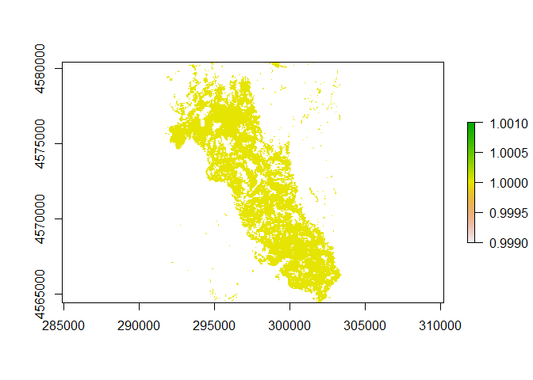

```r
dNBR[dNBR<100] <- NA
dNBR[!is.na(dNBR)] <- 1

plot(dNBR)
```

Whenever we have the **Burnt Area Raster**, we vectorize it to obtain the **fire permimeter**.

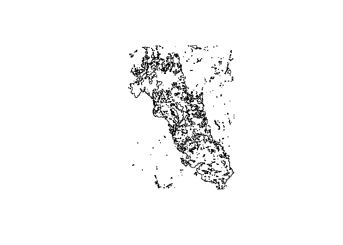

```r
pol <- rasterToPolygons(dNBR,dissolve = T)


perimeter <- as(pol,"SpatialLinesDataFrame")
plot(perimeter)
```

## 1.9 Mapping our results

Additionaly, we can map our results using `leaflet` library wit the following code

```r
leaflet(spTransform(perimeter,CRSobj = CRS("+init=epsg:4326")))%>%
  addTiles(group = "OSM (default)")%>%
  addProviderTiles(providers$Esri.WorldImagery,group = "Imagery")%>%
  addPolylines(color = "red", group = "Perimeter",opacity = 1,weight = 0.5)%>%
  addRasterImage(projectRaster((nbr.pre-nbr.post)*1000, crs=CRS("+init=epsg:4326")),group = "dNBR")%>%
  addLayersControl(
    baseGroups = c("OSM (default)", "Imagery"),
    overlayGroups = c("Perimeter", "dNBR"),
    options = layersControlOptions(collapsed = FALSE)
  )
```

[interactive chart not shown]